# Using Machine Learning to Detect Mistakes in Weight-Lifting Exercises

Ivan Corneillet

## Executive Summary

This project aims to reproduce the machine learning section of Velloso et al.’s [paper](http://groupware.les.inf.puc-rio.br/public/papers/2013.Velloso.QAR-WLE.pdf) on qualitative activity recognition of weight-lifting exercises. In their paper, the authors assessed whether techniques on activity recognition (i.e., predict “which” activity as performed) could be extended to quality of execution (i.e., predict “how well” said activity was performed).

We built a number of prediction models and selected a high-performing random forest (`rf`) machine learning algorithm. Boosting (`gbm`) was a close second followed by naive bayes classifier (`nb`) and linear discriminant analysis (`lda`). Trees (`rpart`) finished last. Finally, we used our random forest model to successfully predict 20 different test cases.

## Model

### `classe` variable (outcome)

In this experiment, six participants were asked to perform sets of ten repetitions of the unilateral dumbbell biceps curl both correctly (i.e., exactly according to the specification) (Class A) as well as incorrectly, following a pattern of four common mistakes: Throwing the elbows to the front (Class B), lifting the dumbbell only halfway (Class C), lowering the dumbbell only halfway (Class D), and throwing the hips to the front (Class E).

### Features (predictors)

In this section, we will examine which features we will include in our model.

#### IMUs’ raw data: `{gyros, accel, magnet}_{belt, arm, dumbbell, forearm}_{x, y, z}`

For data recording, the authors used four [inertial measurement units (IMU)](http://en.wikipedia.org/wiki/Inertial_measurement_unit) that they mounted in the users’ lumbar belt (`_belt_`), glove (`_arm_`), dumbbell (`_dumbbell_`), and armband (`_forearm_`). Each IMO provided three-axes (`_x`, `_y`, and `_z`) gyroscope (`gyros_`), acceleration (`accel_`), and magnetometer (`magnet_`) data, totaling 36 features: `{gyros, accel, magnet}_{belt, arm, dumbbell, forearm}_{x, y, z}`. This raw data is complete (i.e., there are no missing values) for each observation (row) in the training data and we will be including them in our model.

#### IMUs’ calculated data: `{roll, pitch, yaw}_{belt, arm, dumbbell, forearm}` and `total_accel_{belt, arm, dumbbell, forearm}`

For each IMU, the authors also calculated the [Euler angles](http://en.wikipedia.org/wiki/Euler_angles)’ roll (`roll_`), pitch (`pitch_`), and yaw (`yaw_`): `{roll, pitch, yaw}_{belt, arm, dumbbell, forearm}` as well as its total acceleration (``total_accel_`): `total_accel_{belt, arm, dumbbell, forearm}`.

These variables were calculated for each observation in the training data and there are no missing values so we will be including these variables in our model as well.

#### Statistical data; by time window, not by observation

Finally, the authors calculated statistical measures over time windows (mean, variance, standard deviation, max, min, amplitude, kurtosis, and skewness) for the Euler angles of each of the four sensors. However, because we need to predict the class for each of the testing database’s 20 measurements **independently** of any other data, we will not incorporate the statistical features in our machine learning model. This is one difference with what the authors examined in their paper.

The table below summarizes the list of features we selected/didn’t select from the dataset and why:

| Dataset variables | Included in our model? | Notes |
| --- | --- | --- |
| `{gyros, accel, magnet}_{belt, arm, dumbbell, forearm}_{x, y, z}` | **Yes** | IMUs’ raw data; available for each observation in the dataset |
| `{roll, pitch, yaw}_{belt, arm, dumbbell, forearm}` and `total_accel_{belt, arm, dumbbell, forearm}` | **Yes** | IMUs’ calculated data; available for each observation in the dataset |
| Other variables (mean, variance, standard deviation, max, min, amplitude, kurtosis, and skewness) | **No** | Statistical measures over time windows; not available observations we need to predict the outcome in the testing set |

Therefore, our machine learning algorithms will be fed the following dataset: (the code is available in the Appendix)

```
## 'data.frame':    19622 obs. of  53 variables:
##  $ roll_belt           : num  1.41 1.41 1.42 1.48 1.48 1.45 1.42 1.42 1.43 1.45 ...
##  $ pitch_belt          : num  8.07 8.07 8.07 8.05 8.07 8.06 8.09 8.13 8.16 8.17 ...
##  $ yaw_belt            : num  -94.4 -94.4 -94.4 -94.4 -94.4 -94.4 -94.4 -94.4 -94.4 -94.4 ...
##  $ total_accel_belt    : num  3 3 3 3 3 3 3 3 3 3 ...
##  $ gyros_belt_x        : num  0 0.02 0 0.02 0.02 0.02 0.02 0.02 0.02 0.03 ...
##  $ gyros_belt_y        : num  0 0 0 0 0.02 0 0 0 0 0 ...
##  $ gyros_belt_z        : num  -0.02 -0.02 -0.02 -0.03 -0.02 -0.02 -0.02 -0.02 -0.02 0 ...
##  $ accel_belt_x        : num  -21 -22 -20 -22 -21 -21 -22 -22 -20 -21 ...
##  $ accel_belt_y        : num  4 4 5 3 2 4 3 4 2 4 ...
##  $ accel_belt_z        : num  22 22 23 21 24 21 21 21 24 22 ...
##  $ magnet_belt_x       : num  -3 -7 -2 -6 -6 0 -4 -2 1 -3 ...
##  $ magnet_belt_y       : num  599 608 600 604 600 603 599 603 602 609 ...
##  $ magnet_belt_z       : num  -313 -311 -305 -310 -302 -312 -311 -313 -312 -308 ...
##  $ roll_arm            : num  -128 -128 -128 -128 -128 -128 -128 -128 -128 -128 ...
```

[output cut: 39 more lines]

## Partitioning the `training` dataset into training, validation, and testing

The file `ml-testing.csv` is the set we will be using our model to predict the class of each observation; it isn’t the set we will be testing our algorithms. For that, we are further partitioning our `ml-training.csv` dataset into training (56%), validation (19%), and testing (25%):

```r
# Partition the 'ml-training.csv` dataset into training, validation, and testing

set.seed(0) # Set a seed for reproducibility

partition <- createDataPartition(y = training.csv.df$classe, p = 0.75, list = FALSE)
testing <- training.csv.df[-partition, ] # Testing
training.validation <- training.csv.df[partition, ]

partition <- createDataPartition(y = training.validation$classe, p = 0.75, list = FALSE)
training <- training.validation[partition, ] # Training
validation <- training.validation[-partition, ] # Validation
```

```r
nrow(training)
```

```
## [1] 11040
```

```r
nrow(validation)
```

```
## [1] 3678
```

```r
nrow(testing)
```

```
## [1] 4904
```

## Exploratory Data Analysis

### Exploratory plots for the `_belt_` predictors

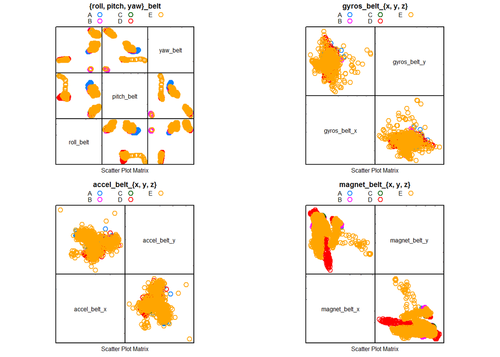

## Models

We ran multiple machine learning algorithms: trees (`rpart`), random forests (`rf`), boosting (`gbm`), naive bayes (`nb`), and linear discriminant analysis (`lda`) with different pre-processing: `none`, `center-and-scale`, and `pca` (which includes `center-and-scale`) as well as different training methods: `default` (`boot`), `cv` (10-fold cross-validation), and `rcv` (five separate 10-fold cross-validations).

The table below summarizes the different combinations we examined:

| Method | Pre-processing | Resampling |
| --- | --- | --- |
| Recursive Partitioning And Regression Trees (`rpart`) | `none` | Simple bootstrap (`boot`) |
| Random Forests (`rf`) | Center and Scale (`center-and-scale`) | 10-fold cross-validation (`cv`) |
| Gradient Boosting Machines (`gbm`) | Principal Component Analysis (`pca`) | Five separate 10-fold cross-validations (`rcv`) |
| Naive Bayes classifier (`nb`) |  |  |
| Linear Discriminant Analysis (`lda`) |  |  |

The results are shown below. `rf` performed the best ($accuracy = 97\%; out-of-sample-error = 1 - accuracy = 3\%$. `PCA` lowered `rf`’s accuracy quite dramatically but any other combination without `PCA` seems to be perform similarly. The second best-performing algorithm was `gbm` ($accuracy \approx 94\%$); `nb` and `lda` were distant third ($accuracy \approx 74\%$ and $accuracy \approx 71\%$) and `rpart` closed the mark with a poor performance ($accuracy \approx 50\%$).

|  | Training accuracy (%) | Validation accuracy (%) | Out-of-sample validation error (%) |
| --- | --- | --- | --- |
| rpart (Default) | 49 | 50 | 50 |
| rpart (Center and Scale) | 49 | 50 | 50 |
| rpart (PCA) | 34 | 34 | 66 |
| rpart (CV) | 49 | 50 | 50 |
| rpart (Center and Scale) (CV) | 49 | 50 | 50 |
| rpart (PCA) (CV) | 34 | 34 | 66 |
| rpart (Repeated CV) | 49 | 50 | 50 |
| rpart (Center and Scale) (Repeated CV) | 49 | 50 | 50 |
| rpart (PCA) (Repeated CV) | 34 | 34 | 66 |
| rf (Default) | 97 | 97 | 3 |
| rf (Center and Scale) | 97 | 97 | 3 |
| rf (PCA) | 91 | 91 | 9 |
| rf (CV) | 97 | 97 | 3 |
| rf (Center and Scale) (CV) | 97 | 97 | 3 |
| rf (PCA) (CV) | 91 | 91 | 9 |
| rf (Repeated CV) | 97 | 97 | 3 |
| rf (Center and Scale) (Repeated CV) | 97 | 97 | 3 |
| rf (PCA) (Repeated CV) | 91 | 91 | 9 |
| gbm (Default) | 95 | 94 | 6 |
| gbm (Center and Scale) | 95 | 94 | 6 |
| gbm (PCA) | 79 | 79 | 21 |
| gbm (CV) | 95 | 94 | 6 |
| gbm (Center and Scale) (CV) | 95 | 94 | 6 |
| gbm (PCA) (CV) | 80 | 80 | 20 |
| gbm (Repeated CV) | 95 | 94 | 6 |
| gbm (Center and Scale) (Repeated CV) | 95 | 94 | 6 |
| gbm (PCA) (Repeated CV) | 80 | 80 | 20 |
| nb (Default) | 75 | 74 | 26 |
| nb (Center and Scale) | 75 | 74 | 26 |
| nb (PCA) | 66 | 64 | 36 |
| nb (CV) | 75 | 74 | 26 |
| nb (Center and Scale) (CV) | 75 | 74 | 26 |
| nb (PCA) (CV) | 66 | 64 | 36 |
| nb (Repeated CV) | 75 | 74 | 26 |
| nb (Center and Scale) (Repeated CV) | 75 | 74 | 26 |
| nb (PCA) (Repeated CV) | 66 | 64 | 36 |
| lda (Default) | 70 | 71 | 29 |
| lda (Center and Scale) | 70 | 71 | 29 |
| lda (PCA) | 53 | 53 | 47 |
| lda (CV) | 70 | 71 | 29 |
| lda (Center and Scale) (CV) | 70 | 71 | 29 |
| lda (PCA) (CV) | 53 | 53 | 47 |
| lda (Repeated CV) | 70 | 71 | 29 |
| lda (Center and Scale) (Repeated CV) | 70 | 71 | 29 |
| lda (PCA) (Repeated CV) | 53 | 53 | 47 |

Because `rf (Default)` gives such good results, we are selecting it as our predictive model. It would seem therefore that our use of separate `validation` and `testing` set wasn’t warranted. However, if we had to go back and tune our models, we would still have a pristine `testing` set to validate our out-of-sample error once we were ready to pick a model.

|  | Training accuracy (%) | Validation accuracy (%) | Out-of-sample validation error (%) | Testing Accuracy (%) | Out-of-sample testing error (%) |
| --- | --- | --- | --- | --- | --- |
| rf (Default) | 97 | 97 | 3 | 99 | 1 |

Our out-of-sample eror for the `testing` set ($1\%$) is in line with the `validation` out-of-sample eror ($3\%$), if not slightly better.

Finally, applying our final model to the observations in the `ml-testing.csv` file, we predict that these observations below to the following classes:

|  | id #1 | id #2 | id #3 | id #4 | id #5 | id #6 | id #7 | id #8 | id #9 | id #10 | id #11 | id #12 | id #13 | id #14 | id #15 | id #16 | id #17 | id #18 | id #19 | id #20 |
| --- | --- | --- | --- | --- | --- | --- | --- | --- | --- | --- | --- | --- | --- | --- | --- | --- | --- | --- | --- | --- |
| rf (Default) | B | A | B | A | A | E | D | B | A | A | B | C | B | A | E | E | A | B | B | B |

This concludes our report. Please feel free to peruse the Appendix for more details (mostly geared towards our implementation).

# Appendix

## Code - Load the `training` dataset with our shortlist of 52 features

```r
features.colClasses = c(
    # Belt
    ########

    # Roll, pitch, yaw, and acceleration data:
    #   '{roll, pitch, yaw, total_accel}_belt' variables

    rep(x = 'numeric', times = 4),

    rep(x = 'NULL', times = 25), # Skip statistical summary variables

    # Three-axes gyroscope, acceleration, and magnetometer data:
    #   '{gyro, accel, magnet}_belt_{x, y, z}' variables

    rep(x = 'numeric', times = 9),

    # Arm
    #######

    # Roll, pitch, yaw, and acceleration data:
    #   '{roll, pitch, yaw, total_accel}_arm' variables

    rep(x = 'numeric', times = 4),

    rep(x = 'NULL', times = 10), # Skip statistical summary variables

    # Three-axes gyroscope, acceleration, and magnetometer data:
    #   '{gyro, accel, magnet}_arm_{x, y, z}' variables

    rep(x = 'numeric', times = 9),

    rep(x = 'NULL', times = 15), # Skip statistical summary variables

    # Dumbbell
    ############

    # Roll, pitch, yaw data:
    #   '{roll, pitch, yaw}_dumbbell' variables

    rep(x = 'numeric', times = 3),

    rep(x = 'NULL', times = 15), # Skip statistical summary variables

    # Acceleration data:
    #   '{total_accel}_dumbbell' variable

    rep(x = 'numeric', times = 1),

    rep(x = 'NULL', times = 10), # Skip statistical summary variables

    # Three-axes gyroscope, acceleration, and magnetometer data:
    #   '{gyro, accel, magnet}_dumbbell_{x, y, z}' variables

    rep(x = 'numeric', times = 9),

    # Forearm
    ###########

    # Roll, pitch, yaw data:
    #   '{roll, pitch, yaw}_forearm' variables

    rep(x = 'numeric', times = 3),

    rep(x = 'NULL', times = 15), # Skip statistical summary variables

    # Acceleration data:
    #   '{total_accel}_forearm' variable

    rep(x = 'numeric', times = 1),

    rep(x = 'NULL', times = 10), # Skip statistical summary variables

    # Three-axes gyroscope, acceleration, and magnetometer data:
    #   '{gyro, accel, magnet}_dumbbell_{x, y, z}' variables

    rep(x = 'numeric', times = 9))

# Load 'pml-training.csv'
###########################

training.csv.df <- read.csv(file = 'pml-training.csv',
    header = TRUE,
    na.strings = c('', 'NA', '#DIV/0!'),
    colClasses = c(
        'NULL', # Row name
        'NULL', # 'user_name',
        rep(x = 'NULL', times = 3), # Timestamp
        rep(x = 'NULL', times = 2), # Window

        # Features
        ############

        features.colClasses,

        # Classe
        ##########

        'character')) %>%
    mutate(classe = factor(x = classe,
        levels = c('A', 'B', 'C', 'D', 'E')))
```

## Code - Load the `testing` dataset with our feature list

```r
# Load 'pml-training.csv'
###########################

testing.csv.df <- read.csv(file = 'pml-testing.csv',
    header = TRUE,
    na.strings = c('', 'NA', '#DIV/0!'),
    colClasses = c(
        'NULL', # Row name
        'NULL', # 'user_name',
        rep(x = 'NULL', times = 3), # Timestamp
        rep(x = 'NULL', times = 2), # Window

        # Features
        ############

        features.colClasses,

        # Problem Id
        ##############

        'numeric'))
```

## `testing` dataset variables

```r
str(testing.csv.df)
```

```
## 'data.frame':    20 obs. of  53 variables:
##  $ roll_belt           : num  123 1.02 0.87 125 1.35 -5.92 1.2 0.43 0.93 114 ...
##  $ pitch_belt          : num  27 4.87 1.82 -41.6 3.33 1.59 4.44 4.15 6.72 22.4 ...
##  $ yaw_belt            : num  -4.75 -88.9 -88.5 162 -88.6 -87.7 -87.3 -88.5 -93.7 -13.1 ...
##  $ total_accel_belt    : num  20 4 5 17 3 4 4 4 4 18 ...
##  $ gyros_belt_x        : num  -0.5 -0.06 0.05 0.11 0.03 0.1 -0.06 -0.18 0.1 0.14 ...
##  $ gyros_belt_y        : num  -0.02 -0.02 0.02 0.11 0.02 0.05 0 -0.02 0 0.11 ...
##  $ gyros_belt_z        : num  -0.46 -0.07 0.03 -0.16 0 -0.13 0 -0.03 -0.02 -0.16 ...
##  $ accel_belt_x        : num  -38 -13 1 46 -8 -11 -14 -10 -15 -25 ...
##  $ accel_belt_y        : num  69 11 -1 45 4 -16 2 -2 1 63 ...
##  $ accel_belt_z        : num  -179 39 49 -156 27 38 35 42 32 -158 ...
##  $ magnet_belt_x       : num  -13 43 29 169 33 31 50 39 -6 10 ...
##  $ magnet_belt_y       : num  581 636 631 608 566 638 622 635 600 601 ...
##  $ magnet_belt_z       : num  -382 -309 -312 -304 -418 -291 -315 -305 -302 -330 ...
##  $ roll_arm            : num  40.7 0 0 -109 76.1 0 0 0 -137 -82.4 ...
```

[output cut: 39 more lines]

## No missing data and no zero variance predictors in the datasets

```r
sum(colSums(is.na(training.csv.df)))
```

```
## [1] 0
```

```r
nearZeroVar(x = select(training.csv.df, -c(classe)))
```

```
## integer(0)
```

```r
sum(colSums(is.na(testing.csv.df)))
```

```
## [1] 0
```

```r
nearZeroVar(x = select(testing.csv.df, -c(problem_id)))
```

```
## integer(0)
```

## Exploratory Analysis

### Exploratory plots for the `_arm_` predictors

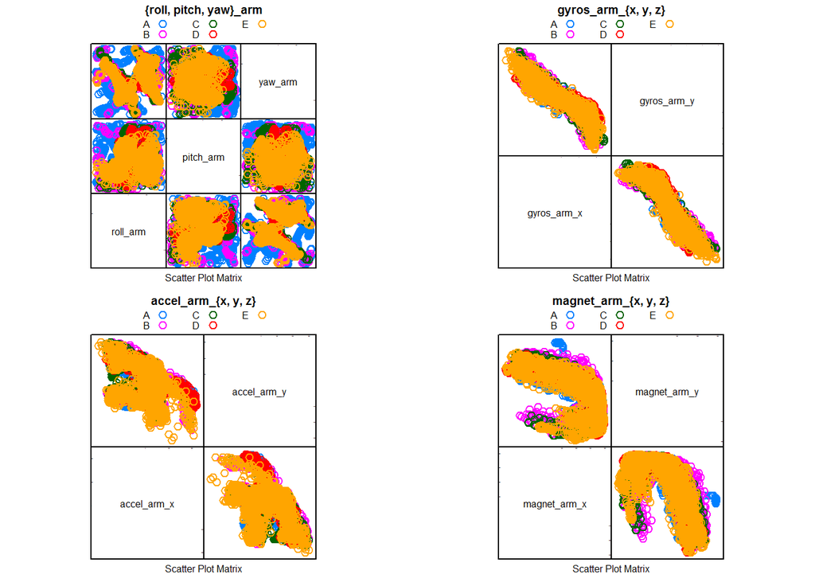

### Exploratory plots for the `_dumbbell_` predictors

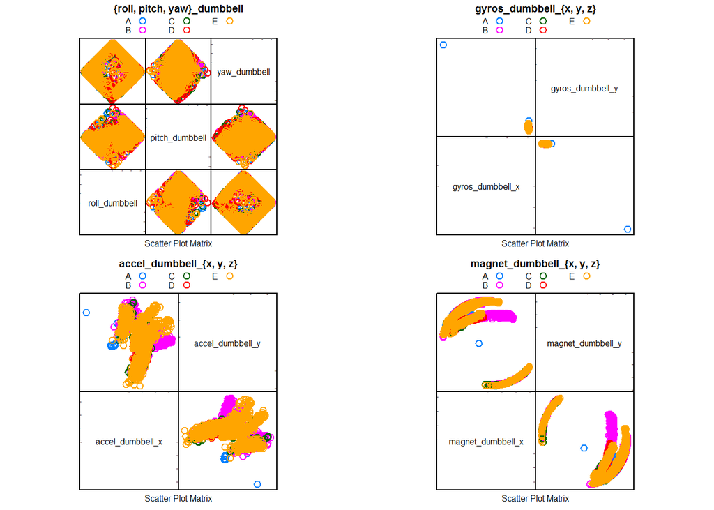